# FashionMNIST Classification Report

```python
import numpy as np
import torch
import torch.nn as nn
import torch.optim as optim

# PyTorch TensorBoard support
# from torch.utils.tensorboard import SummaryWriter
# import torchvision
# import torchvision.transforms as transforms

from datetime import datetime

import torchvision
import torchvision.transforms as transforms

from torchvision.datasets import FashionMNIST
import matplotlib.pyplot as plt
%matplotlib inline

from torch.utils.data import random_split
from torch.utils.data import DataLoader
import torch.nn.functional as F

from PIL import Image
#import torchvision.transforms as T
```

```python
# load the dataset
mnist_dataset = FashionMNIST(root = 'data/', download=True, train = True, transform = transforms.ToTensor())
print(mnist_dataset)
```

```
Dataset FashionMNIST
    Number of datapoints: 60000
    Root location: data/
    Split: Train
    StandardTransform
Transform: ToTensor()
```

```
torch.Size([1, 28, 28]) 0
tensor([[[0.6510, 0.5961, 0.6196, 0.6196, 0.6275],
         [0.6235, 0.6000, 0.6157, 0.6196, 0.6353],
         [0.6196, 0.6078, 0.6353, 0.6196, 0.6275],
         [0.5961, 0.6275, 0.6196, 0.6314, 0.6275],
         [0.5765, 0.6431, 0.6078, 0.6471, 0.6314]]])
tensor(1.) tensor(0.)
```

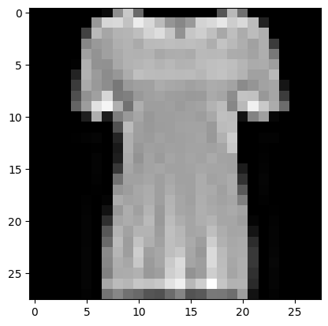

```python
sampleTensor, label = mnist_dataset[10]
print(sampleTensor.shape, label)
tpil = transforms.ToPILImage() # using the __call__ to
image = tpil(sampleTensor)
image.show()

print(sampleTensor[:,10:15,10:15])
print(torch.max(sampleTensor), torch.min(sampleTensor))
plt.imshow(sampleTensor[0,:,:],cmap = 'gray')
```

[figure not shown]

```python
figure = plt.figure(figsize=(10, 8))
cols, rows = 5, 5
for i in range(1, cols * rows + 1):
    sample_idx = torch.randint(len(mnist_dataset), size=(1,)).item()
    img, label = mnist_dataset[sample_idx]
    figure.add_subplot(rows, cols, i)
    plt.title(label)
    plt.axis("off")
    plt.imshow(img.squeeze(), cmap="gray")
plt.show()
```

```
tensor([[[0.6510, 0.5961, 0.6196, 0.6196, 0.6275],
         [0.6235, 0.6000, 0.6157, 0.6196, 0.6353],
         [0.6196, 0.6078, 0.6353, 0.6196, 0.6275],
         [0.5961, 0.6275, 0.6196, 0.6314, 0.6275],
         [0.5765, 0.6431, 0.6078, 0.6471, 0.6314]]])
tensor(1.) tensor(0.)
```

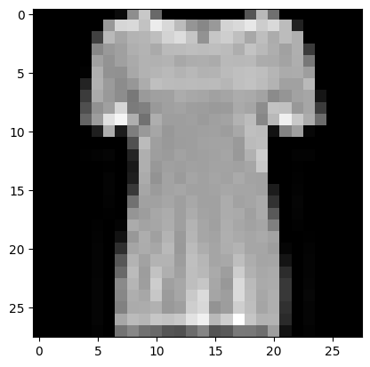

```python
print(sampleTensor[:,10:15,10:15])
print(torch.max(sampleTensor), torch.min(sampleTensor))
plt.imshow(sampleTensor[0,:,:],cmap = 'gray')
```

## Training and validation data

```python
import random
import numpy as np
import torch
```

```python
def set_seed(seed=42):
    import random, numpy as np, torch
    random.seed(seed)
    np.random.seed(seed)
    torch.manual_seed(seed)
    torch.backends.cudnn.deterministic = True
    torch.backends.cudnn.benchmark = False
    if torch.cuda.is_available():
        torch.cuda.manual_seed(seed)
```

```python
set_seed(42)
train_data, validation_data = random_split(mnist_dataset, [50000, 10000])
print("length of Train Datasets: ", len(train_data))
print("length of Validation Datasets: ", len(validation_data))
batch_size = 128
train_loader = DataLoader(train_data, batch_size, shuffle = True)
val_loader = DataLoader(validation_data, batch_size, shuffle = False)

test_dataset = FashionMNIST(root = 'data/', train = False, transform = transforms.ToTensor())
print("Length of Test Datasets: ", len(test_dataset))
test_loader = DataLoader(test_dataset, batch_size = 256, shuffle = False)
```

```
length of Train Datasets:  50000
length of Validation Datasets:  10000
Length of Test Datasets:  10000
```

## Multi-class Logistic Regression (a building block of DNN)

```python
input_size = 28 * 28
num_classes = 10

model = nn.Linear(input_size, num_classes)
```

```python
class MnistModel(nn.Module):
    def __init__(self):
        super().__init__()
        self.linear = nn.Linear(input_size, num_classes)

    def forward(self, xb):

        xb = xb.reshape(-1, 784)
        print(xb)
        out = self.linear(xb)
        print(out)
        return(out)

model = MnistModel()
print(model.linear.weight.shape, model.linear.bias.shape)
list(model.parameters())
```

```
torch.Size([10, 784]) torch.Size([10])
```

```
[Parameter containing:
 tensor([[-0.0216, -0.0002,  0.0216,  ..., -0.0019,  0.0124,  0.0127],
         [ 0.0136, -0.0146, -0.0044,  ...,  0.0235,  0.0101, -0.0236],
         [ 0.0117, -0.0311,  0.0118,  ..., -0.0048, -0.0241, -0.0098],
         ...,
         [-0.0156,  0.0337, -0.0106,  ...,  0.0161, -0.0286,  0.0338],
         [-0.0150,  0.0143,  0.0289,  ...,  0.0313,  0.0228,  0.0018],
         [-0.0326,  0.0056, -0.0050,  ..., -0.0004,  0.0215, -0.0033]],
        requires_grad=True),
 Parameter containing:
 tensor([ 0.0163, -0.0108, -0.0153,  0.0178,  0.0141,  0.0070,  0.0168, -0.0173,
          0.0101, -0.0066], requires_grad=True)]
```

```python
for images, labels in train_loader:
    outputs = model(images)
    break

print('Outputs shape: ', outputs.shape) # torch.Size([128, 10])
print('Sample outputs: \n', outputs[:2].data) # example outputs
```

```
tensor([[0., 0., 0.,  ..., 0., 0., 0.],
        [0., 0., 0.,  ..., 0., 0., 0.],
        [0., 0., 0.,  ..., 0., 0., 0.],
        ...,
        [0., 0., 0.,  ..., 0., 0., 0.],
        [0., 0., 0.,  ..., 0., 0., 0.],
        [0., 0., 0.,  ..., 0., 0., 0.]])
tensor([[-0.0094, -0.0817, -0.1211,  ...,  0.2350,  0.1469, -0.2173],
        [-0.4221, -0.3317, -0.0429,  ...,  0.4576,  0.2599, -0.1079],
        [-0.5464, -0.2055, -0.1849,  ...,  0.5065,  0.0249, -0.3272],
        ...,
        [-0.0929, -0.1872, -0.0379,  ...,  0.5234,  0.1786, -0.2591],
        [-0.2822, -0.2415, -0.1125,  ...,  0.4214,  0.3273, -0.1996],
        [-0.0490, -0.2018, -0.0346,  ...,  0.2430,  0.0299, -0.2727]],
       grad_fn=<AddmmBackward0>)
Outputs shape:  torch.Size([128, 10])
Sample outputs:
 tensor([[-0.0094, -0.0817, -0.1211,  0.1978, -0.0480, -0.0303, -0.0608,  0.2350,
          0.1469, -0.2173],
        [-0.4221, -0.3317, -0.0429,  0.2193,  0.2906, -0.3222, -0.7132,  0.4576,
          0.2599, -0.1079]])
```

## Softmax function

```python
probs = F.softmax(outputs, dim = 1)

print("Sample probabilities:\n", probs[:2].data)

# print(preds)
# print("\n")
# print(max_probs)
```

```
Sample probabilities:
 tensor([[0.0980, 0.0912, 0.0876, 0.1206, 0.0943, 0.0960, 0.0931, 0.1251, 0.1146,
         0.0796],
        [0.0662, 0.0725, 0.0967, 0.1257, 0.1350, 0.0732, 0.0495, 0.1596, 0.1309,
         0.0907]])
```

## Evaluation Metric and Loss Function

```python
# accuracy calculation
def accuracy(outputs, labels):
    _, preds = torch.max(outputs, dim = 1)
    return(torch.tensor(torch.sum(preds == labels).item()/ len(preds)))

print("Accuracy: ", accuracy(outputs, labels))
print("\n")
loss_fn = F.cross_entropy
print("Loss Function: ",loss_fn)
print("\n")
## Loss for the current batch
loss = loss_fn(outputs, labels)
print(loss)
```

```
Accuracy:  tensor(0.1406)


Loss Function:  <function cross_entropy at 0x7b8e77b6a7a0>


tensor(2.3384, grad_fn=<NllLossBackward0>)
```

## Cross-Entropy

```python
class MnistModel(nn.Module):
    def __init__(self):
        super().__init__()
        self.linear = nn.Linear(input_size, num_classes)

    def forward(self, xb):
        xb = xb.reshape(-1, 784)
        out = self.linear(xb)
        return(out)

    # We add extra methods
    def training_step(self, batch):
        # when training, we compute the cross entropy, which help us update weights
        images, labels = batch
        out = self(images) ## Generate predictions
        loss = F.cross_entropy(out, labels) ## Calculate the loss
        return(loss)

    def validation_step(self, batch):
        images, labels = batch
        out = self(images) ## Generate predictions
        loss = F.cross_entropy(out, labels) ## Calculate the loss
        # in validation, we want to also look at the accuracy
        # idealy, we would like to save the model when the accuracy is the highest.
        acc = accuracy(out, labels) ## calculate metrics/accuracy
        return({'val_loss':loss, 'val_acc': acc})

    def validation_epoch_end(self, outputs):
        # at the end of epoch (after running through all the batches)
        batch_losses = [x['val_loss'] for x in outputs]
        epoch_loss = torch.stack(batch_losses).mean()
        batch_accs = [x['val_acc'] for x in outputs]
        epoch_acc = torch.stack(batch_accs).mean()
        return({'val_loss': epoch_loss.item(), 'val_acc' : epoch_acc.item()})

    def epoch_end(self, epoch,result):
        # log epoch, loss, metrics
        print("Epoch [{}], val_loss: {:.4f}, val_acc: {:.4f}".format(epoch, result['val_loss'], result['val_acc']))

# we instantiate the model
model = MnistModel()

# a simple helper function to evaluate
def evaluate(model, data_loader):
    # for batch in data_loader, run validation_step
    outputs = [model.validation_step(batch) for batch in data_loader]
    return(model.validation_epoch_end(outputs))

# actually training
def fit(epochs, lr, model, train_loader, val_loader, opt_func = torch.optim.SGD):
    history = []
    optimizer = opt_func(model.parameters(), lr)
    for epoch in range(epochs):
        ## Training Phase
        for batch in train_loader:
            loss = model.training_step(batch)
            loss.backward() ## backpropagation starts at the loss and goes through all layers to model inputs
            optimizer.step() ## the optimizer iterate over all parameters (tensors); use their stored grad to update their values
            optimizer.zero_grad() ## reset gradients

        ## Validation phase
        result = evaluate(model, val_loader)
        model.epoch_end(epoch, result)
        history.append(result)
    return(history)
```

```python
# test the functions, with a randomly initialized model (weights are random, e.g., untrained)
result0 = evaluate(model, val_loader)
result0
```

```
{'val_loss': 2.3042473793029785, 'val_acc': 0.12223101407289505}
```

```python
# let's train for 10 epochs
history1 = fit(10, 0.001, model, train_loader, val_loader)
```

```
Epoch [0], val_loss: 1.6959, val_acc: 0.6432
Epoch [1], val_loss: 1.4158, val_acc: 0.6673
Epoch [2], val_loss: 1.2524, val_acc: 0.6751
Epoch [3], val_loss: 1.1465, val_acc: 0.6824
Epoch [4], val_loss: 1.0718, val_acc: 0.6884
Epoch [5], val_loss: 1.0161, val_acc: 0.6978
Epoch [6], val_loss: 0.9727, val_acc: 0.7055
Epoch [7], val_loss: 0.9375, val_acc: 0.7116
Epoch [8], val_loss: 0.9084, val_acc: 0.7217
Epoch [9], val_loss: 0.8837, val_acc: 0.7284
```

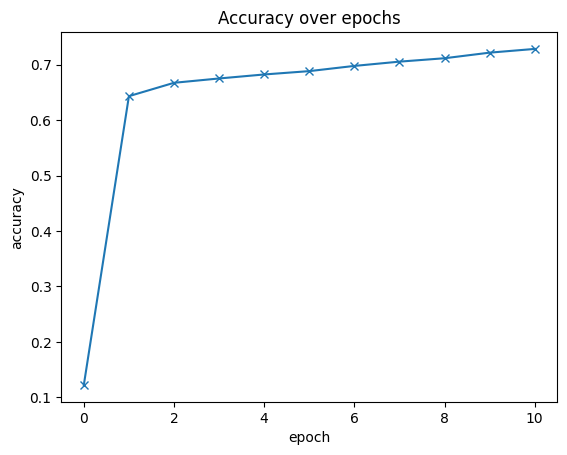

```python
# we combine the first result (no training) and the training results of 5 epoches
# plotting accuracy
history = [result0] + history1
accuracies = [result['val_acc'] for result in history]
plt.plot(accuracies, '-x')
plt.xlabel('epoch')
plt.ylabel('accuracy')
plt.title('Accuracy over epochs')
```

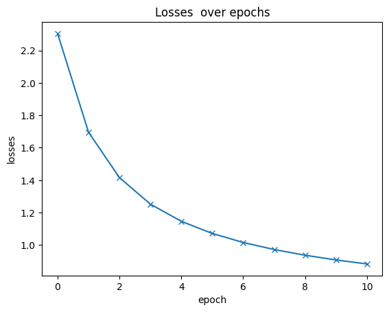

```python
# plotting losses
history = [result0] + history1
losses = [result['val_loss'] for result in history]
plt.plot(losses, '-x')
plt.xlabel('epoch')
plt.ylabel('losses')
plt.title('Losses  over epochs')
```

## Final check using the (held-out) test dataset.

```
Shape:  torch.Size([1, 28, 28])
Label:  9
```

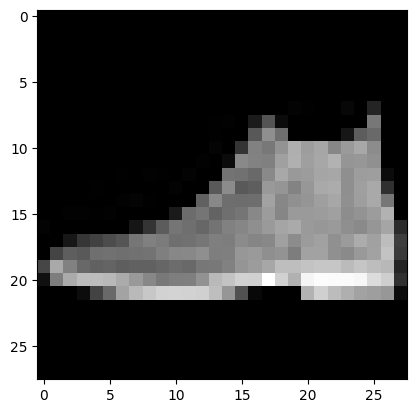

```python
img, label = test_dataset[0]
plt.imshow(img[0], cmap = 'gray')
print("Shape: ", img.shape)
print('Label: ', label)
```

```python
def predict_image(img, model):
    xb = img.unsqueeze(0)
    yb = model(xb)
    _, preds = torch.max(yb, dim = 1)
    return(preds[0].item())
```

```python
img, label = test_dataset[0]
print('Label:', label, ', Predicted :', predict_image(img, model))
```

```
Label: 9 , Predicted : 9
```

```python
result = evaluate(model, test_loader)
result
```

```
{'val_loss': 0.8970500230789185, 'val_acc': 0.7049804925918579}
```

# Convolutional Neural Network (CNN)

```python
class CNN(nn.Module):
    def __init__(self):
        super(CNN, self).__init__()
        self.conv1 = nn.Sequential(
            nn.Conv2d(
                in_channels=1,
                out_channels=16,
                kernel_size=5,
                stride=1,
                padding=2,
            ),
            nn.ReLU(),
            nn.MaxPool2d(kernel_size=2),
        )
        self.conv2 = nn.Sequential(
            nn.Conv2d(16, 32, 5, 1, 2),
            nn.ReLU(),
            nn.MaxPool2d(2),
        )
        # fully connected layer, output 10 classes
        self.out = nn.Linear(32 * 7 * 7, 10)
    def forward(self, x):
        x = self.conv1(x)
        x = self.conv2(x)
        # flatten the output of conv2 to (batch_size, 32 * 7 * 7)
        x = x.view(x.size(0), -1)
        output = self.out(x)
        return output, x    # return x for visualization

set_seed(42)
cnn = CNN()
print(cnn)
```

```
CNN(
  (conv1): Sequential(
    (0): Conv2d(1, 16, kernel_size=(5, 5), stride=(1, 1), padding=(2, 2))
    (1): ReLU()
    (2): MaxPool2d(kernel_size=2, stride=2, padding=0, dilation=1, ceil_mode=False)
  )
  (conv2): Sequential(
    (0): Conv2d(16, 32, kernel_size=(5, 5), stride=(1, 1), padding=(2, 2))
    (1): ReLU()
    (2): MaxPool2d(kernel_size=2, stride=2, padding=0, dilation=1, ceil_mode=False)
  )
  (out): Linear(in_features=1568, out_features=10, bias=True)
)
```

```python
set_seed(42)

loss_func = nn.CrossEntropyLoss()
loss_func

optimizer = optim.Adam(cnn.parameters(), lr = 0.01)
optimizer
```

```
Adam (
Parameter Group 0
    amsgrad: False
    betas: (0.9, 0.999)
    capturable: False
    differentiable: False
    eps: 1e-08
    foreach: None
    fused: None
    lr: 0.01
    maximize: False
    weight_decay: 0
)
```

```python
from torch.autograd import Variable

def train(num_epochs, cnn, loaders):
    cnn.train()
    optimizer = optim.Adam(cnn.parameters(), lr = 0.01)
    loss_func = nn.CrossEntropyLoss()
    # Train the model
    total_step = len(loaders)

    for epoch in range(num_epochs):
        for i, (images, labels) in enumerate(loaders):

            # gives batch data, normalize x when iterate train_loader
            b_x = Variable(images)   # batch x
            b_y = Variable(labels)   # batch y
            output = cnn(b_x)[0]
            loss = loss_func(output, b_y)

            # clear gradients for this training step
            optimizer.zero_grad()

            # backpropagation, compute gradients
            loss.backward()
            # apply gradients
            optimizer.step()

            if (i+1) % 100 == 0:
                print ('Epoch [{}/{}], Step [{}/{}], Loss: {:.4f}'.format(epoch + 1, num_epochs, i + 1, total_step, loss.item()))
                pass
        pass
    pass
```

```python
set_seed(42)
cnn.eval()
with torch.no_grad():
    correct = 0
    total = 0
    for images, labels in train_loader:
        test_output, _ = cnn(images)
        pred_y = torch.max(test_output, 1)[1]
        correct += (pred_y == labels).sum().item()
        total += labels.size(0)

accuracy = correct / total
print('Training Accuracy on full set: %.2f' % accuracy)
```

```
Training Accuracy on full set: 0.06
```

```python
set_seed(42)
train(num_epochs=5, cnn=cnn, loaders=train_loader)
```

```
Epoch [1/5], Step [100/391], Loss: 0.6872
Epoch [1/5], Step [200/391], Loss: 0.4290
Epoch [1/5], Step [300/391], Loss: 0.4893
Epoch [2/5], Step [100/391], Loss: 0.4447
Epoch [2/5], Step [200/391], Loss: 0.3351
Epoch [2/5], Step [300/391], Loss: 0.3095
Epoch [3/5], Step [100/391], Loss: 0.3744
Epoch [3/5], Step [200/391], Loss: 0.3450
Epoch [3/5], Step [300/391], Loss: 0.3287
Epoch [4/5], Step [100/391], Loss: 0.2811
Epoch [4/5], Step [200/391], Loss: 0.3105
Epoch [4/5], Step [300/391], Loss: 0.3809
Epoch [5/5], Step [100/391], Loss: 0.3618
Epoch [5/5], Step [200/391], Loss: 0.2982
Epoch [5/5], Step [300/391], Loss: 0.3318
```

# Evaluate the model on test data

```python
cnn.eval()
with torch.no_grad():
    correct = 0
    total = 0
    for images, labels in train_loader:
        test_output, _ = cnn(images)
        pred_y = torch.max(test_output, 1)[1]
        correct += (pred_y == labels).sum().item()
        total += labels.size(0)

accuracy = correct / total
print('Test Accuracy: %.2f' % accuracy)
```

```
Test Accuracy: 0.91
```

```python
cnn.eval()
with torch.no_grad():
    correct = 0
    total = 0
    for images, labels in test_loader:
        test_output, _ = cnn(images)
        pred_y = torch.max(test_output, 1)[1]
        correct += (pred_y == labels).sum().item()
        total += labels.size(0)

accuracy = correct / total
print('Test Accuracy: %.2f' % accuracy)
```

```
Test Accuracy: 0.89
```

Run inference on individual images

```python
sample = next(iter(test_loader))
imgs, lbls = sample

actual_number = lbls[:10].numpy()
actual_number

test_output, last_layer = cnn(imgs[:10])
pred_y = torch.max(test_output, 1)[1].data.numpy().squeeze()
print(f'Prediction number: {pred_y}')
print(f'Actual number: {actual_number}')
```

```
Prediction number: [9 2 1 1 6 1 4 6 5 7]
Actual number: [9 2 1 1 6 1 4 6 5 7]
```

## CNN after tuning

```python
import torch.nn as nn

class CNN(nn.Module):
    def __init__(self):
        super(CNN, self).__init__()

        self.conv1 = nn.Sequential(
            nn.Conv2d(1, 32, kernel_size=3, padding=1),  # 28x28 → 28x28
            nn.BatchNorm2d(32),
            nn.ReLU(),
            nn.MaxPool2d(2)                              # 28x28 → 14x14
        )

        self.conv2 = nn.Sequential(
            nn.Conv2d(32, 64, kernel_size=3, padding=1), # 14x14 → 14x14
            nn.BatchNorm2d(64),
            nn.ReLU(),
            nn.MaxPool2d(2)                              # 14x14 → 7x7
        )

        self.conv3 = nn.Sequential(
            nn.Conv2d(64, 128, kernel_size=3, padding=1),# 7x7 → 7x7
            nn.BatchNorm2d(128),
            nn.ReLU(),
            nn.MaxPool2d(2)                              # 7x7 → 3x3
        )

        self.dropout = nn.Dropout(0.5)
        self.fc = nn.Sequential(
            nn.Linear(128 * 3 * 3, 256),
            nn.ReLU(),
            nn.Dropout(0.5),
            nn.Linear(256, 10)
        )

    def forward(self, x):
        x = self.conv1(x)
        x = self.conv2(x)
        x = self.conv3(x)
        x = x.view(x.size(0), -1)
        x = self.dropout(x)
        output = self.fc(x)
        return output, x

set_seed(42)
cnn = CNN()
print(cnn)
```

```
CNN(
  (conv1): Sequential(
    (0): Conv2d(1, 32, kernel_size=(3, 3), stride=(1, 1), padding=(1, 1))
    (1): BatchNorm2d(32, eps=1e-05, momentum=0.1, affine=True, track_running_stats=True)
    (2): ReLU()
    (3): MaxPool2d(kernel_size=2, stride=2, padding=0, dilation=1, ceil_mode=False)
  )
  (conv2): Sequential(
    (0): Conv2d(32, 64, kernel_size=(3, 3), stride=(1, 1), padding=(1, 1))
    (1): BatchNorm2d(64, eps=1e-05, momentum=0.1, affine=True, track_running_stats=True)
    (2): ReLU()
    (3): MaxPool2d(kernel_size=2, stride=2, padding=0, dilation=1, ceil_mode=False)
  )
  (conv3): Sequential(
    (0): Conv2d(64, 128, kernel_size=(3, 3), stride=(1, 1), padding=(1, 1))
    (1): BatchNorm2d(128, eps=1e-05, momentum=0.1, affine=True, track_running_stats=True)
    (2): ReLU()
    (3): MaxPool2d(kernel_size=2, stride=2, padding=0, dilation=1, ceil_mode=False)
  )
  (dropout): Dropout(p=0.5, inplace=False)
  (fc): Sequential(
    (0): Linear(in_features=1152, out_features=256, bias=True)
    (1): ReLU()
    (2): Dropout(p=0.5, inplace=False)
    (3): Linear(in_features=256, out_features=10, bias=True)
  )
)
```

```python
set_seed(42)
loss_func = nn.CrossEntropyLoss()
loss_func

optimizer = optim.Adam(cnn.parameters(), lr = 0.001)
optimizer
```

```
Adam (
Parameter Group 0
    amsgrad: False
    betas: (0.9, 0.999)
    capturable: False
    differentiable: False
    eps: 1e-08
    foreach: None
    fused: None
    lr: 0.001
    maximize: False
    weight_decay: 0
)
```

```python
from torch.autograd import Variable

def train(num_epochs, cnn, loaders):
    cnn.train()
    optimizer = optim.Adam(cnn.parameters(), lr = 0.001)
    loss_func = nn.CrossEntropyLoss()
    # Train the model
    total_step = len(loaders)

    for epoch in range(num_epochs):
        for i, (images, labels) in enumerate(loaders):

            # gives batch data, normalize x when iterate train_loader
            b_x = Variable(images)   # batch x
            b_y = Variable(labels)   # batch y
            output = cnn(b_x)[0]
            loss = loss_func(output, b_y)

            # clear gradients for this training step
            optimizer.zero_grad()

            # backpropagation, compute gradients
            loss.backward()
            # apply gradients
            optimizer.step()

            if (i+1) % 100 == 0:
                print ('Epoch [{}/{}], Step [{}/{}], Loss: {:.4f}'.format(epoch + 1, num_epochs, i + 1, total_step, loss.item()))
                pass
        pass
    pass
```

```python
set_seed(42)
train(num_epochs=10, cnn=cnn, loaders=train_loader)
```

```
Epoch [1/10], Step [100/391], Loss: 0.5510
Epoch [1/10], Step [200/391], Loss: 0.4487
Epoch [1/10], Step [300/391], Loss: 0.4367
Epoch [2/10], Step [100/391], Loss: 0.2917
Epoch [2/10], Step [200/391], Loss: 0.3134
Epoch [2/10], Step [300/391], Loss: 0.2365
Epoch [3/10], Step [100/391], Loss: 0.3980
Epoch [3/10], Step [200/391], Loss: 0.3138
Epoch [3/10], Step [300/391], Loss: 0.2783
Epoch [4/10], Step [100/391], Loss: 0.3194
Epoch [4/10], Step [200/391], Loss: 0.3367
Epoch [4/10], Step [300/391], Loss: 0.2244
Epoch [5/10], Step [100/391], Loss: 0.2869
Epoch [5/10], Step [200/391], Loss: 0.3367
Epoch [5/10], Step [300/391], Loss: 0.2376
Epoch [6/10], Step [100/391], Loss: 0.2096
Epoch [6/10], Step [200/391], Loss: 0.2559
Epoch [6/10], Step [300/391], Loss: 0.1561
Epoch [7/10], Step [100/391], Loss: 0.2845
Epoch [7/10], Step [200/391], Loss: 0.2189
Epoch [7/10], Step [300/391], Loss: 0.1489
Epoch [8/10], Step [100/391], Loss: 0.1774
Epoch [8/10], Step [200/391], Loss: 0.2055
Epoch [8/10], Step [300/391], Loss: 0.1078
Epoch [9/10], Step [100/391], Loss: 0.2699
Epoch [9/10], Step [200/391], Loss: 0.1894
Epoch [9/10], Step [300/391], Loss: 0.2709
Epoch [10/10], Step [100/391], Loss: 0.2242
Epoch [10/10], Step [200/391], Loss: 0.1860
Epoch [10/10], Step [300/391], Loss: 0.1830
```

```python
cnn.eval()
with torch.no_grad():
    correct = 0
    total = 0
    for images, labels in train_loader:
        test_output, _ = cnn(images)
        pred_y = torch.max(test_output, 1)[1]
        correct += (pred_y == labels).sum().item()
        total += labels.size(0)

accuracy = correct / total
print('Test Accuracy: %.2f' % accuracy)
```

```
Test Accuracy: 0.94
```

```python
cnn.eval()
with torch.no_grad():
    correct = 0
    total = 0
    for images, labels in test_loader:
        test_output, _ = cnn(images)
        pred_y = torch.max(test_output, 1)[1]
        correct += (pred_y == labels).sum().item()
        total += labels.size(0)

accuracy = correct / total
print('Test Accuracy: %.2f' % accuracy)
```

```
Test Accuracy: 0.91
```

```python
sample = next(iter(test_loader))
imgs, lbls = sample

actual_number = lbls[:10].numpy()
actual_number

test_output, last_layer = cnn(imgs[:10])
pred_y = torch.max(test_output, 1)[1].data.numpy().squeeze()
print(f'Prediction number: {pred_y}')
print(f'Actual number: {actual_number}')
```

```
Prediction number: [9 2 1 1 6 1 4 6 5 7]
Actual number: [9 2 1 1 6 1 4 6 5 7]
```

# **Results**

## 🧠 Model 2: Basic CNN

### **Architecture Description**

- **Two convolutional layers**:
  - First layer: 16 filters, 5×5 kernel
  - Second layer: 32 filters, 5×5 kernel
- Each layer uses:
  - ReLU activation
  - 2×2 Max Pooling
- **Fully connected layer**:
  - Single linear layer that maps the 32 feature maps (7×7) to 10 output classes

### **Hyperparameters**

- **Learning Rate**: 0.01
- **Optimizer**: Adam
- **Batch Size**: 128
- **Epochs**: 5

### **Performance**

- **Training Accuracy**: 91%
- **Testing Accuracy**: 89%

## 🧠 Model 3: Tuned CNN (Improved Architecture)

This model improves upon the basic CNN by increasing the depth, using more filters, and applying regularization techniques such as Batch Normalization and Dropout.

### **Architecture Description**

- **Three convolutional layers**:
  - First layer: 32 filters, 3×3 kernel
  - Second layer: 64 filters, 3×3 kernel
  - Third layer: 128 filters, 3×3 kernel
- Each convolutional layer is followed by:
  - Batch Normalization
  - ReLU activation
  - 2×2 Max Pooling
- **Fully connected layers**:
  - First: 256 neurons with ReLU
  - Second: 10 output classes
- **Dropout (p = 0.5)** is applied after the last convolutional layer and between the two fully connected layers.

### **Performance**

- **Training Accuracy**: 94%
- **Testing Accuracy**: 91%

> This model achieves the best performance out of the three, thanks to deeper architecture, improved feature extraction, and regularization techniques that reduce overfitting.